# Final project of microarray analysis Alexis Molina

## Summary of the project

Analysis of microarray data of GSE112497 using Bioconductor.

### Summary of the data

Analysis of gene expression in human CAFs with control (shCtrl) or shRNA against NNMT (shNNMT) expression or normal fibroblasts expressing control (Ctrl) or NNMT overexpression (NNMT) constructs. Cells were infected with lentivirus to express the indicated shRNA construct. Hypothesis is that knockdown of NNMT will affect expression of genes via regulation of histone methylation status.

### Overall design

Total RNA was collected from human cancer associated fibroblasts expressing the indicated shCtrl or shNNMT constructs or from normal WI-38 fibroblasts expressing Ctrl or NNMT constructs and expression analyzed with Affymetrix microarray.

## Citations

Eckert MA, Coscia F, Chryplewicz A, Chang JW et al. Proteomics reveals NNMT as a master metabolic regulator of cancer-associated fibroblasts. Nature 2019 May;569(7758):723-728. PMID: 31043742

#### Load the needed packages before using the code, those can be found in the script

#### Targets summary

There are 12 samples which can be joined into 4 groups: ShCtrl, ShNNMT, Ctrl, NNMT

```r
targets <- read.csv('./data/targets.csv', header = T,sep = ',')
targets
```

```
##       Samples Short_Name  Grups     Colors
## 1  GSM3071363   ShCtrl-1 ShCtrl turquoise2
## 2  GSM3071364   ShCtrl-2 ShCtrl turquoise2
## 3  GSM3071365   ShCtrl-3 ShCtrl turquoise2
## 4  GSM3071366   ShNNMT-1 ShNNMT    tomato2
## 5  GSM3071367   ShNNMT-2 ShNNMT    tomato2
## 6  GSM3071368   ShNNMT-3 ShNNMT    tomato2
## 7  GSM3071369     Ctrl-1   Ctrl  seashell3
## 8  GSM3071370     Ctrl-2   Ctrl  seashell3
## 9  GSM3071371     Ctrl-3   Ctrl  seashell3
## 10 GSM3071372     NNMT-1   NNMT  seagreen3
## 11 GSM3071373     NNMT-2   NNMT  seagreen3
## 12 GSM3071374     NNMT-3   NNMT  seagreen3
```

Reading cel files and getting into rawData to use later

Getting variables for plots

```r
sampleNames <- as.character(targets$Short_Name)
sampleColor <- as.character(targets$Colors)
```

#### Quality control by boxplot, PCA and cluster of rawData

Here we check the quality of our data looking for outliers, artifacts, etc

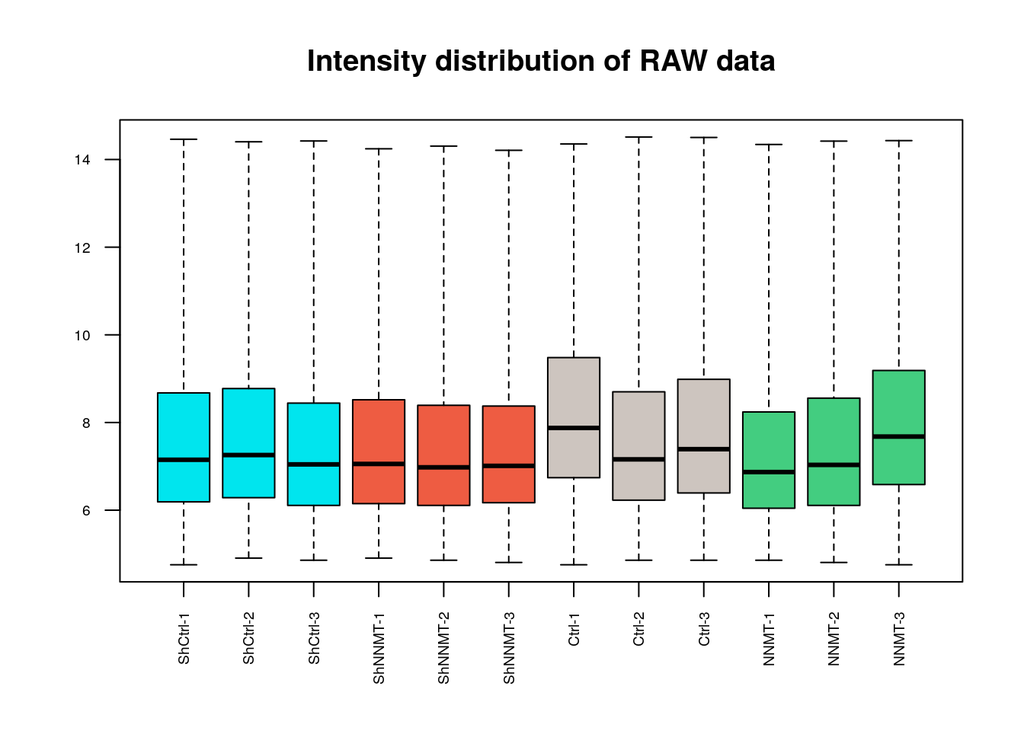

```r
boxplot(rawData, which="all",las=2, main="Intensity distribution of RAW data",
        cex.axis=0.6, col=sampleColor, names=sampleNames)
```

Data seems to be ok with some variation, but without erros or strange values, some samples seem to look more alike, we will check it with clustering and PCA

Now we cluster data

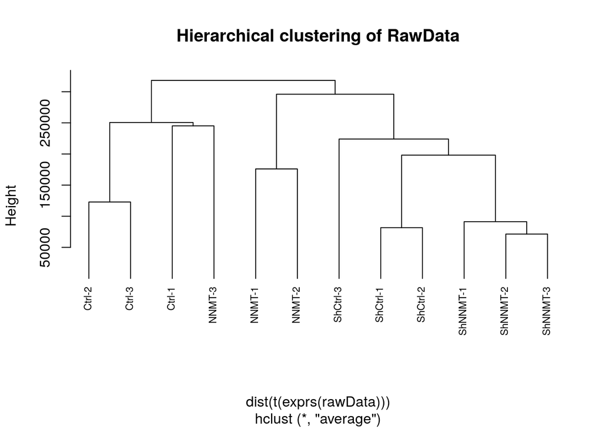

```r
clust.euclid.averageR <- hclust(dist(t(exprs(rawData))),method="average")
plot(clust.euclid.averageR, labels=sampleNames, main="Hierarchical clustering of RawData",
     cex=0.7,  hang=-1)
```

Clusters of this plot are supported by the fact that they have samples that look alike in the boxplot.

Now we do PCA of the data

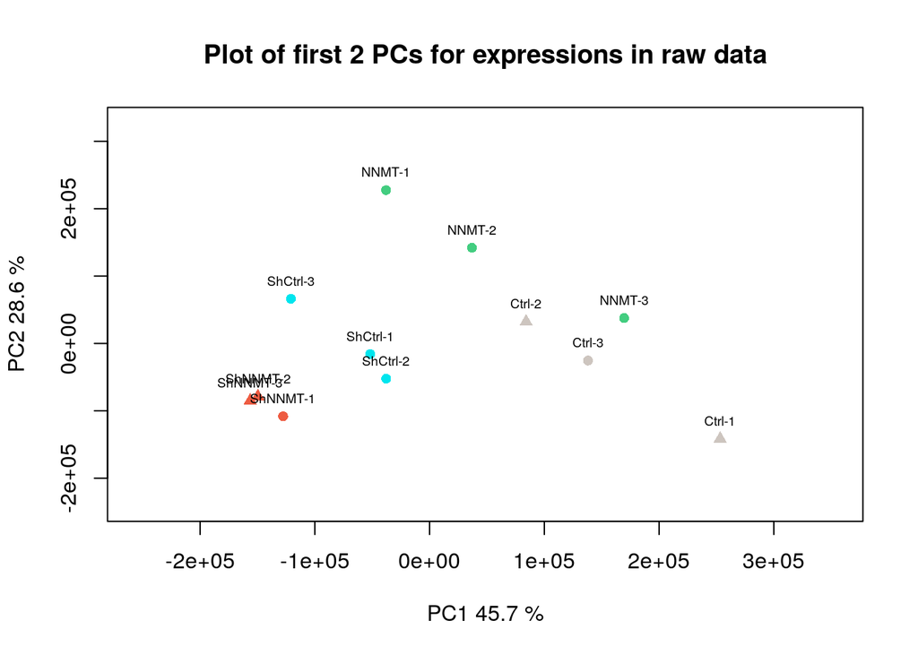

```r
plotPCA <- function ( X, labels=NULL, colors=NULL, dataDesc="", scale=FALSE, formapunts=NULL, myCex=0.8,...)
{
  pcX<-prcomp(t(X), scale=scale) # o prcomp(t(X))
  loads<- round(pcX$sdev^2/sum(pcX$sdev^2)*100,1)
  xlab<-c(paste("PC1",loads[1],"%"))
  ylab<-c(paste("PC2",loads[2],"%"))
  if (is.null(colors)) colors=1
  plot(pcX$x[,1:2],xlab=xlab,ylab=ylab, col=colors, pch=formapunts,
       xlim=c(min(pcX$x[,1])-100000, max(pcX$x[,1])+100000),ylim=c(min(pcX$x[,2])-100000, max(pcX$x[,2])+100000))
  text(pcX$x[,1],pcX$x[,2], labels, pos=3, cex=myCex)
  title(paste("Plot of first 2 PCs for expressions in", dataDesc, sep=" "), cex=0.8)
}

plotPCA(exprs(rawData), labels=sampleNames, dataDesc="raw data", colors=sampleColor,
        formapunts=c(rep(16,4),rep(17,4)), myCex=0.6)
```

PCA shows as that some groups are really clustered like SHNNMT and others are pretty distinct like Ctrl or NNMT.

#### Data normalization and analysis

Here we normalize data to get rid of possible artifacts or errors and check how it changes after the procedure

Redo boxplot, Clustering and PCA

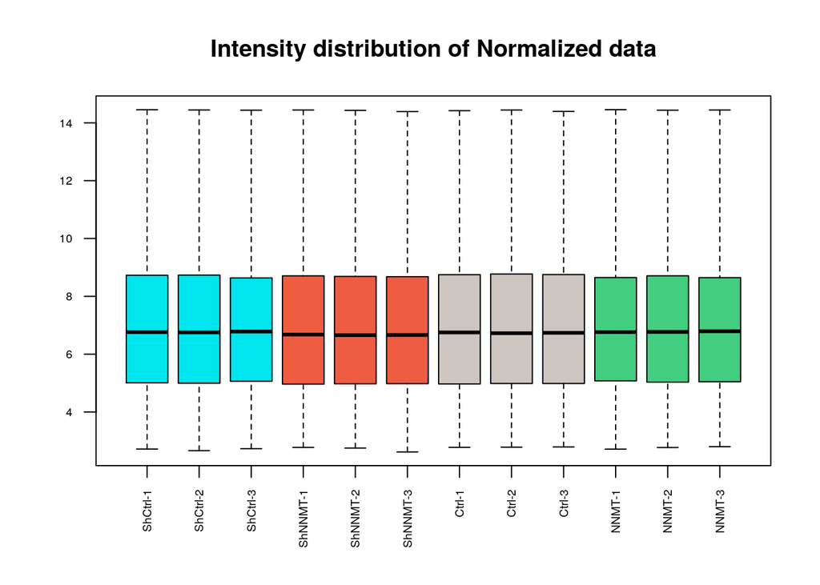

```r
#BOXPLOT
boxplot(eset, las=2, main="Intensity distribution of Normalized data", cex.axis=0.6,
        col=sampleColor, names=sampleNames)
```

We can see that data has close to no differences between the observations now, so we may have lost some statistical information, but also some possible artifacts are also lost, so it seems to be worth it

Now we redo clustering and check for the groups

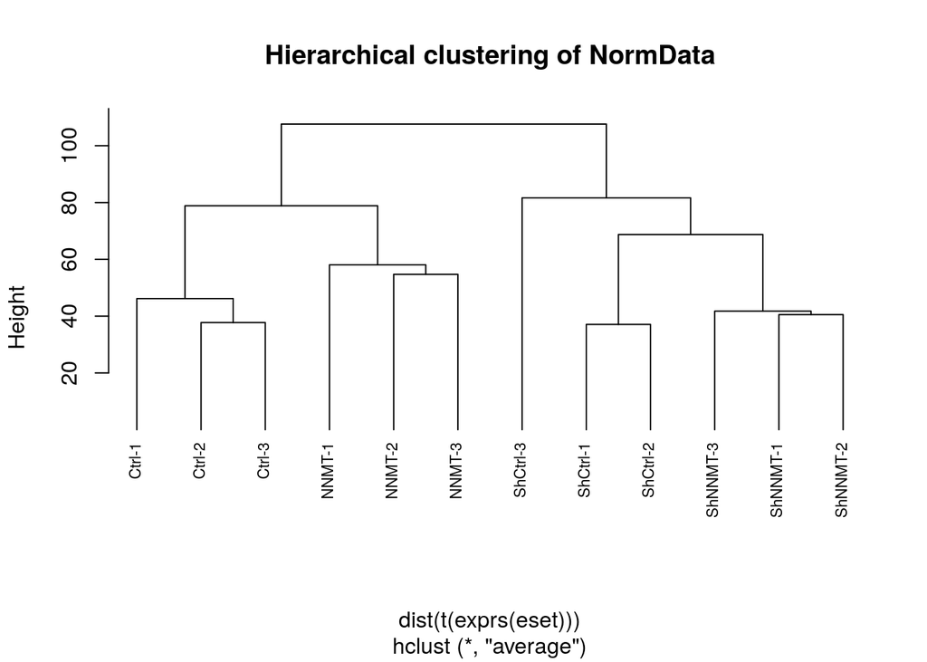

```r
clust.euclid.averageN <- hclust(dist(t(exprs(eset))),method="average")
plot(clust.euclid.averageN, labels=sampleNames, main="Hierarchical clustering of NormData",
     cex=0.7,  hang=-1)
```

We repeat PCA

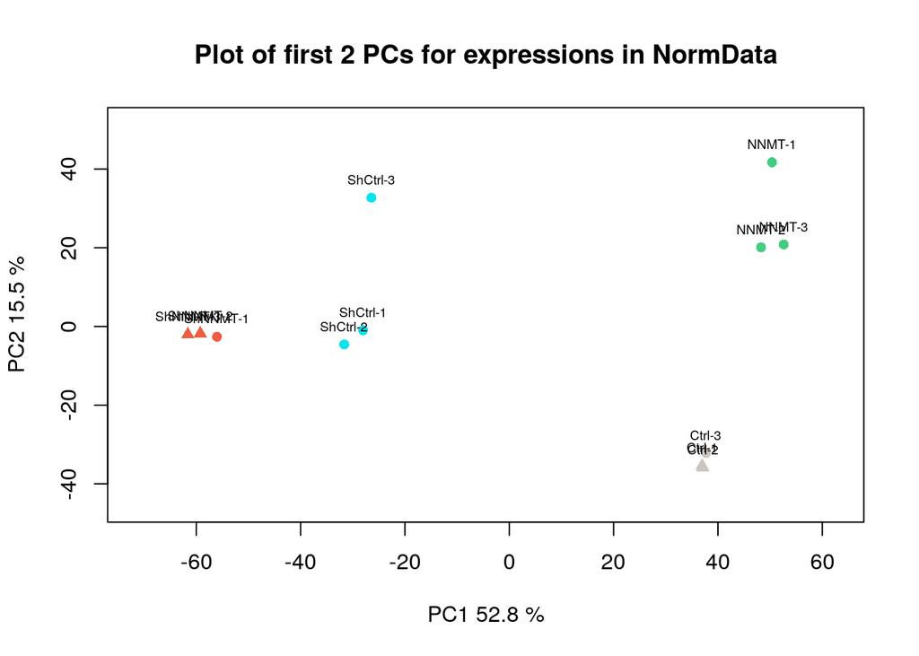

```r
plotPCA <- function ( X, labels=NULL, colors=NULL, dataDesc="", scale=FALSE, formapunts=NULL, myCex=0.8,...)
{
  pcX<-prcomp(t(X), scale=scale) # o prcomp(t(X))
  loads<- round(pcX$sdev^2/sum(pcX$sdev^2)*100,1)
  xlab<-c(paste("PC1",loads[1],"%"))
  ylab<-c(paste("PC2",loads[2],"%"))
  if (is.null(colors)) colors=1
  plot(pcX$x[,1:2],xlab=xlab,ylab=ylab, col=colors, pch=formapunts,
       xlim=c(min(pcX$x[,1])-10, max(pcX$x[,1])+10),ylim=c(min(pcX$x[,2])-10, max(pcX$x[,2])+10))
  text(pcX$x[,1],pcX$x[,2], labels, pos=3, cex=myCex)
  title(paste("Plot of first 2 PCs for expressions in", dataDesc, sep=" "), cex=0.8)
}

plotPCA(exprs(eset), labels=sampleNames, dataDesc="NormData", colors=sampleColor,
        formapunts=c(rep(16,4),rep(17,4)), myCex=0.6)
```

Now samles of the same experiment are togetherm which means that the expression of genes between the types of experiments which is good.

#### Array quality matrices

Here we check for the corectness of data once more to verify the previous statements

Number of genes that are out

```r
print(eset_filtered$filter.log$numLowVar)
```

```
## [1] 20341
```

Genes that are still used

```r
print(eset_filtered$eset)
```

```
## ExpressionSet (storageMode: lockedEnvironment)
## assayData: 6780 features, 12 samples
##   element names: exprs
## protocolData
##   rowNames: GSM3071363_ME_1_Clariom_S_Human.CEL
##     GSM3071364_ME_2_Clariom_S_Human.CEL ...
##     GSM3071374_ME_12_Clariom_S_Human.CEL (12 total)
##   varLabels: exprs dates
##   varMetadata: labelDescription channel
## phenoData
##   rowNames: GSM3071363_ME_1_Clariom_S_Human.CEL
##     GSM3071364_ME_2_Clariom_S_Human.CEL ...
##     GSM3071374_ME_12_Clariom_S_Human.CEL (12 total)
##   varLabels: index
##   varMetadata: labelDescription channel
## featureData: none
## experimentData: use 'experimentData(object)'
## Annotation: org.Mm.eg.db
```

#### Design, plots, regression

This is where we are going to create design matrix, contrast matrix and liner model

```r
Groups <- targets$Grups
types <- factor(Groups)
matrix_design <-model.matrix(~0+types)
colnames(matrix_design)<-c("shCtrl","shNNMT","Ctrl","NNMT")
rownames(matrix_design) <- sampleNames
print(matrix_design)
```

```
##          shCtrl shNNMT Ctrl NNMT
## ShCtrl-1      0      0    1    0
## ShCtrl-2      0      0    1    0
## ShCtrl-3      0      0    1    0
## ShNNMT-1      0      0    0    1
## ShNNMT-2      0      0    0    1
## ShNNMT-3      0      0    0    1
## Ctrl-1        1      0    0    0
## Ctrl-2        1      0    0    0
## Ctrl-3        1      0    0    0
## NNMT-1        0      1    0    0
## NNMT-2        0      1    0    0
## NNMT-3        0      1    0    0
## attr(,"assign")
## [1] 1 1 1 1
## attr(,"contrasts")
## attr(,"contrasts")$types
## [1] "contr.treatment"
```

```r
matrix_contrasts <- makeContrasts (
    shCtrlvsshNNMT = shCtrl-shNNMT,
  shCtrlvsCtrl = shCtrl-Ctrl,
   shCtrlvsNNMT= shCtrl-NNMT,
 shNNMTvsCtrl = shNNMT-Ctrl,
shNNMTvsNNMT  = shNNMT-NNMT,
  CtrlvsNNMT=Ctrl-NNMT ,
  levels=matrix_design)

matrix_contrasts
```

```
##         Contrasts
## Levels   shCtrlvsshNNMT shCtrlvsCtrl shCtrlvsNNMT shNNMTvsCtrl
##   shCtrl              1            1            1            0
##   shNNMT             -1            0            0            1
##   Ctrl                0           -1            0           -1
##   NNMT                0            0           -1            0
##         Contrasts
## Levels   shNNMTvsNNMT CtrlvsNNMT
##   shCtrl            0          0
##   shNNMT            1          0
##   Ctrl              0          1
##   NNMT             -1         -1
```

Fir linear model with our data

```r
fit1 <- lmFit(eset_filtered$eset, matrix_design)
fit.main1 <- contrasts.fit(fit1, matrix_contrasts)
fit.main1
```

[output not shown]

[output cut: 66 more lines]

```
## 7 more rows ...
##
## $contrasts
##         Contrasts
## Levels   shCtrlvsshNNMT shCtrlvsCtrl shCtrlvsNNMT shNNMTvsCtrl
##   shCtrl              1            1            1            0
##   shNNMT             -1            0            0            1
##   Ctrl                0           -1            0           -1
##   NNMT                0            0           -1            0
##         Contrasts
## Levels   shNNMTvsNNMT CtrlvsNNMT
##   shCtrl            0          0
##   shNNMT            1          0
##   Ctrl              0          1
##   NNMT             -1         -1
```

Accounting for bayes to improve the model

```r
fit.main1 <- eBayes(fit.main1)
fit.main1
```

[output not shown]

[output cut: 146 more lines]

```
##            shNNMTvsNNMT CtrlvsNNMT
##   23064070    2.3035164  -3.758274
##   23064072   -6.6789758  -3.612607
##   23064075    1.6632410  -6.002780
##   23064081   -0.3118434  -6.076969
##   23064083   -3.8248396  -6.503908
## 6775 more rows ...
##
## $F
## [1] 19.833750  8.565622 24.666590 10.179140 13.791463
## 6775 more elements ...
##
## $F.p.value
## [1] 3.807499e-05 2.100596e-03 1.175239e-05 9.956247e-04 2.413819e-04
## 6775 more elements ...
```

#### Toptables of the genes

Once we have fitted our data into a linear model we create a topTable for each comparison to see what genes are differentially expressed between the observations

```r
topTab1_shCtrlvsshNNMT <- topTable (fit.main1, number=nrow(fit.main1), coef="shCtrlvsshNNMT", adjust="fdr");
topTab2_shCtrlvsCtrl <- topTable (fit.main1, number=nrow(fit.main1), coef="shCtrlvsCtrl", adjust="fdr");
topTab3_shCtrlvsNNMT <- topTable (fit.main1, number=nrow(fit.main1), coef="shCtrlvsNNMT", adjust="fdr");
topTab4_shNNMTvsCtrl <- topTable (fit.main1, number=nrow(fit.main1), coef="shNNMTvsCtrl", adjust="fdr");
topTab5_shNNMTvsNNMT<- topTable (fit.main1, number=nrow(fit.main1), coef="shNNMTvsNNMT", adjust="fdr");
topTab6_CtrlvsNNMT <- topTable (fit.main1, number=nrow(fit.main1), coef="CtrlvsNNMT", adjust="fdr");
```

#### Volcano plot

Volcanoplot for the visualization of data

[figure not shown]

```r
volcanoplot(fit.main1, highlight=10, names=fit.main1$ID,
            main = paste("Differentially expressed genes", colnames(matrix_contrasts), sep="\n"))
abline(v = c(-3, 3))
```

We can see a lot of genes that seem to be differentially expressed, we can check heir function to understand what is changed in the cancer cells compared to normal ones.